# FR-Match: A cell type matching algorithm for single cell RNA sequencing (scRNAseq) data

Yun (Renee) Zhang, zhangy@jcvi.org

November 21, 2022 - update raw data link

# Overview

## Workflow

General steps of FR-Match include:

- **Feature selection/dimensionality reduction** using the *supervised* [NS-Forest](https://github.com/JCVenterInstitute/NSForest) marker gene selection algorithm or other *informative* marker gene set per user’s choice. Our choice of the NS-Forest marker gene selection provides a minimum set of marker genes that maximize the classification power of differentiating clusters in the reference dataset.
- Construct **minimum spanning trees** for each pair of query and reference clusters.
- Calculate **FR statistics and p-values** based on the minimum spanning tree plots.

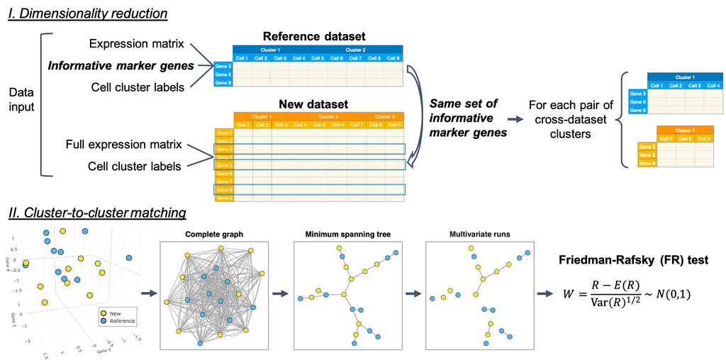

Overview of FR-Match for cross-comparison between two scRNAseq experiments.

## Installation

To install from GitHub repository,

```r
install.packages("devtools")
devtools::install_github("JCVenterInstitute/FRmatch")
```

After successful installation, load FR-Match and other useful packages to your R environment.

```r
library(FRmatch)
library(SingleCellExperiment)
library(dplyr)
library(tibble)
library(data.table)
```

# Getting data ready

## Input data

FR-Match is a cell type matching method for two independently conducted scRNAseq experiments, namely, query and reference. For each experiment, FR-Match takes in the following input data:

- Reference dataset
  - A cell-by-gene expression matrix
  - Cell type cluster membership
  - *Informative* marker genes for the reference cell types
- Query dataset
  - A cell-by-gene expression matrix
  - Cell type cluster membership

There are many pieces of data information needed for various scRNAseq data analyses. We choose to use the `SingleCellExperiment` class to organize the input data, which is a convenient container for scRNAseq data. For instructions on how to construct a `SingleCellExperiment` object, please see [An introduction to the SingleCellExperiment class](https://www.bioconductor.org/packages/devel/bioc/vignettes/SingleCellExperiment/inst/doc/intro.html).

For an FR-Match data object, the following data are essential:

- a gene expression data matrix (`assay()`)
- cell type cluster labels (`colData()`)
- NS-Forest or your own marker genes for the reference dataset (`rowData()`)

In addition, metadata (`@metadata`) such as F-beta score and cluster order are not essential for the core matching algorithm, but these information will facilitate visualization and other customized analysis tools provided in this package.

## An example data object

In this package, we include an example data object `sce.example`. For more details, please see `help("sce.example")`. A quick look at the data object below.

```r
data(sce.example)
sce.example
```

```
#> class: SingleCellExperiment
#> dim: 16497 865
#> metadata(3): cluster_marker_info f_score cluster_order
#> assays(1): logcounts
#> rownames(16497): A1CF A2M ... ZZEF1 ZZZ3
#> rowData names(1): marker_gene
#> colnames(865): A01_1_Nuclei_NeuNP_H200_1025_MTG_layer1_BCH9
#>   A01_BCH3_1NeuNP_H200.1030_MTG_Layer_1 ...
#>   P11_1_Nuclei_NeuNN_H200_1025_MTG_layer1_BCH9
#>   P11_1_Nuclei_NeuNN_H200_1030_MTG_layer1_BCH8
#> colData names(1): cluster_membership
#> reducedDimNames(0):
#> mainExpName: NULL
#> altExpNames(0):
```

The naming convention and data structure are listed below.

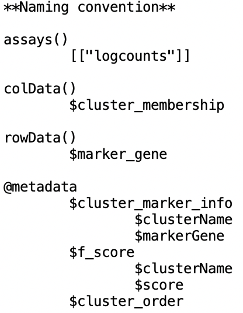

Naming convention of the data object.

## Layer 1 and full MTG data

```r
## rename the data object
sce.layer1 <- sce.example
## cell type clusters and cluster sizes
knitr::kable(table(colData(sce.layer1)$cluster_membership), col.names=c("Cluster", "Size"))
```

| Cluster | Size |
| --- | --- |
| e1_e299_SLC17A7_L5b_Cdh13 | 299 |
| g1_g48_GLI3_Astro_Gja1 | 48 |
| g2_g27_APBB1IP_Micro_Ctss | 27 |
| g3_g18_GPNMB_OPC_Pdgfra | 18 |
| g4_g9_MOG_Oligo_Opalin | 9 |
| i10_i16_TSPAN12_Vip_Mybpc1 | 16 |
| i1_i90_COL5A2_Ndnf_Car4 | 90 |
| i2_i77_LHX6_Sst_Cbln4 | 77 |
| i3_i56_BAGE2_Ndnf_Cxcl14 | 56 |
| i4_i54_MC4R_Ndnf_Cxcl14 | 54 |
| i5_i47_TRPC3_Ndnf_Car4 | 47 |
| i6_i44_GPR149_Vip_Mybpc1 | 44 |
| i7_i31_CLMP_Ndnf_Cxcl14 | 31 |
| i8_i27_SNCG_Vip_Mybpc1 | 27 |
| i9_i22_TAC3_Vip_Mybpc1 | 22 |

The second dataset is sampled from the full laminar depth (layer 1-6) of the MTG cerebral cortex ([Hodge et al., 2019](https://www.nature.com/articles/s41586-019-1506-7)). The MTG dataset consist of 13945 genes and 15603 cells; 75 cell type clusters are identified and labeled by the authors. We are going to devote the next section to introduce a function that compiles the necessary input data files from the MTG dataset into a data object that can be used in our matching function.

## Construct data object using `make_data_object()`

The following raw data files are [here](https://github.com/JCVenterInstitute/celligrate-data/tree/main/AIBS_MTG_data).

```r
## read in pieces of input data - this may take a few minutes
cell_by_gene_expression <- fread("cell_by_gene_expression.csv")
cell_cluster_labels <- fread("cell_cluster_labels.csv")
NSForest_marker_genes <- fread("NSForest_marker_genes.csv")
NSForest_fscores <- fread("NSForest_fscores.csv")
MTG_taxonomy <- fread("MTG_taxonomy.csv")$x #need to be a vector

## unique markers
unique_markers <- unique(NSForest_marker_genes$markerGene)
```

Use the `make_data_object()` function to compile the pieces of input data into a data object.

```r
sce.MTG <- make_data_object(dat = cell_by_gene_expression,
                            tab = cell_cluster_labels,
                            markers = unique_markers,
                            ## below are optional input data
                            cluster_marker_info = NSForest_marker_genes,
                            f_score = NSForest_fscores,
                            cluster_order = MTG_taxonomy)
```

Take a look at the data object for the full MTG.

```r
sce.MTG
```

```
#> class: SingleCellExperiment
#> dim: 13945 15603
#> metadata(3): cluster_marker_info f_score cluster_order
#> assays(1): logcounts
#> rownames(13945): A1BG A2M ... ZZEF1 ZZZ3
#> rowData names(1): marker_gene
#> colnames(15603): F1S4_160106_001_B01 F1S4_160106_001_C01 ...
#>   F2S4_170405_060_F01 F2S4_170405_060_H01
#> colData names(1): cluster_membership
#> reducedDimNames(0):
#> mainExpName: NULL
#> altExpNames(0):
```

*It may cause some confusion on the cell-by-gene or gene-by-cell orientation of the expression data. To be clear, the raw input data (.csv or .txt file) for gene expression should have cells in rows and genes in columns (cell-by-gene). After the input data is read into the data object (e.g. sce.example), the expression data is stored as genes in rows and cells in columns (gene-by-cell). We made such arrangement because conventionally R packages, such as Seurat, deal with gene-by-cell expression data; and Python packages, such as Scanpy, deal with cell-by-gene expression data.*

# FR-Match

## Cell type “barcode”

In the FR-Match workflow, we utilize the informative marker genes for dimensionality reduction. Good marker genes display on-off binary expression pattern producing, in combination, a unique gene expression “barcode” for each cell type cluster. We provide the `plot_cluster_by_markers()` function for plotting the marker gene expression patterns for a random set of cells in each cluster, visualizing the cell type “barcode”. Examples below show that the “barcodes” for excitatory cell type, glial cell type, and inhibitory cell type from the layer 1 data are distinctively different using the NS-Forest marker genes.

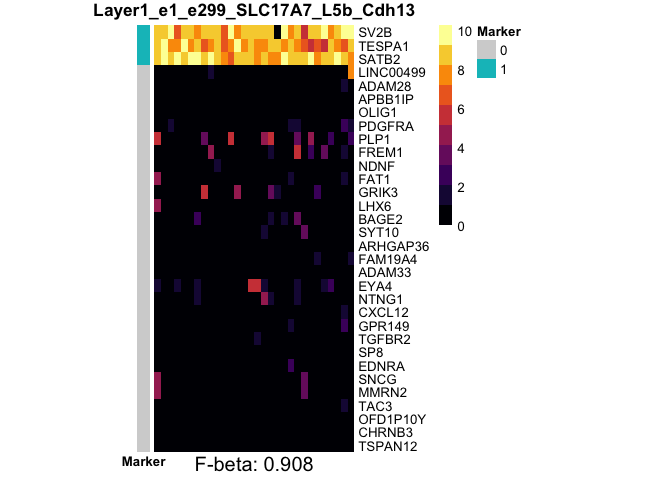

```r
plot_cluster_by_markers(sce.example, cluster.name = "e1_e299_SLC17A7_L5b_Cdh13", name.self = "Layer1_")
```

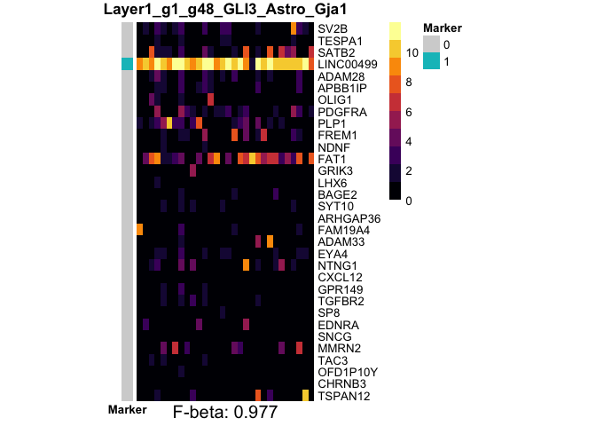

```r
plot_cluster_by_markers(sce.example, cluster.name = "g1_g48_GLI3_Astro_Gja1", name.self = "Layer1_")
```

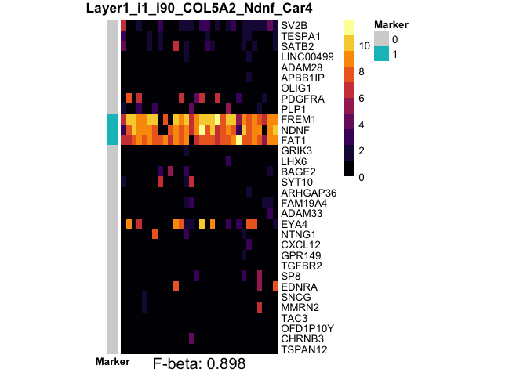

```r
plot_cluster_by_markers(sce.example, cluster.name = "i1_i90_COL5A2_Ndnf_Car4", name.self = "Layer1_")
```

## Cluster sizes

Take a look at the cluster sizes in these two datasets.

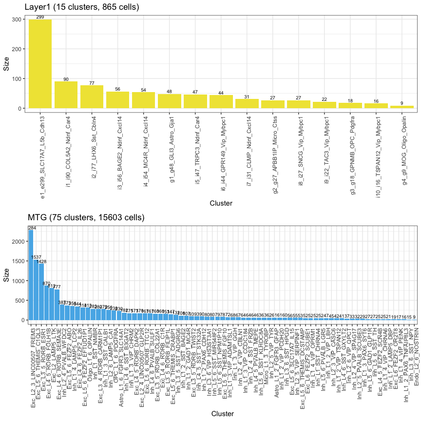

```r
plot_clusterSize(sce.layer1, sce.MTG, name.E1 = "Layer1", name.E2 = "MTG")
```

Note that cluster sizes range widely, which may cause the unbalance cluster size issue in the FR test.

## Run `FRmatch()`

The `FRmatch()` function is a wrapper function that takes in two input data objects in the `sce.query =` and `sce.ref =` arguments. By performing this function, it carries out our matching workflow in default setting. Key steps are reported while running. To start, let’s regard `sce.layer1` as the query data and `sce.MTG` as the reference data.

```r
rst.layer1toMTG <- FRmatch(sce.query = sce.layer1, sce.ref = sce.MTG, subsamp.size = 10)
```

```
#> * Check query data object.
#> * Check reference data object.
#> * Feature selection: 108 out of 157 reference marker genes are presented in the query experiment.
#> * Filtering small clusters: query and reference clusters with less than 5 cells are not considered.
#> * Comparing 15 query clusters with 75 reference clusters...
#> ** Parallel computing with 12 cores.
#> ** method = cluster2cluster | subsamp.size = 10 | subsamp.iter = 1000
#> * Done parallel and returning results.
```

Also, we may want to swap the query and reference data to perform FR-Match in the other direction. In practice, if we want to match between two independently conducted experiments (for example, each experiment may focus on a different specimen region, inducing different cell type clusters and different set of marker genes), different directions of matching may lead to quiet different matching results. We recommend to perform both directions of matching, and conclude with a consensus matching results from both directions.

```r
rst.MTGtolayer1 <- FRmatch(sce.query = sce.MTG, sce.ref = sce.layer1, subsamp.size = 10)
```

```
#> * Check query data object.
#> * Check reference data object.
#> * Feature selection: 30 out of 32 reference marker genes are presented in the query experiment.
#> * Filtering small clusters: query and reference clusters with less than 5 cells are not considered.
#> * Comparing 75 query clusters with 15 reference clusters...
#> ** Parallel computing with 12 cores.
#> ** method = cluster2cluster | subsamp.size = 10 | subsamp.iter = 1000
#> * Done parallel and returning results.
```

The `FRmatch()` output is a list of results. The best way to present these results is to use our customized plotting functions.

## Plot bi-directional matching results

The final matching results from both directions can be combined using the `plot_bi_FRmatch()` function. The function takes in the `FRmatch()` outputs from both directions, and displays the two-way match (match found in both directions), one-way match (match found in either direction), and no match in the following plot.

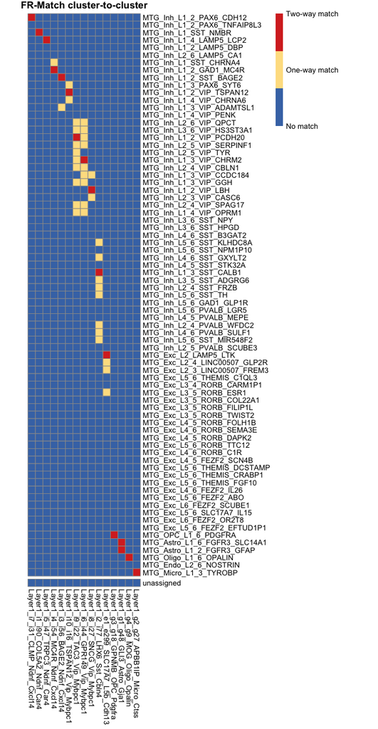

```r
plot_bi_FRmatch(rst.layer1toMTG, rst.MTGtolayer1, name.E1="Layer1_", name.E2="MTG_")
```

## Plot one-directional matching results

We also provide the function `plot_FRmatch()` that takes in single `FRmatch()` output with argument `type = "matches"` by default, and optionally `type = "padj"`, to visualize the matching results from one direction.

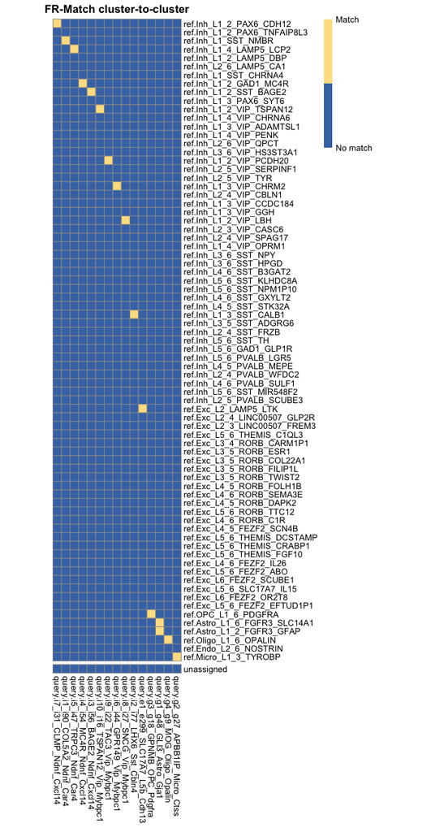

```r
## to visualize the one-directional matches
plot_FRmatch(rst.layer1toMTG)
```

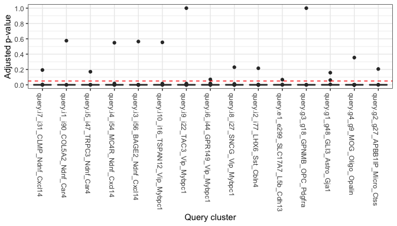

```r
## to visualize the adjusted p-values for each query cluster
plot_FRmatch(rst.layer1toMTG, type = "padj")
```

**A few remarks:**

- For the plots above, note that the prefixes of these cluster names are “query.” and “ref.”, which are coded in our program as default option. We deliberately leave it that way since: 1) it helps our users to distinguish the direction of the one-directional matching; and 2) we sort of regard the one-directional matching as an internal step and strongly recommend to perform the matching in both directions. These prefixes can be changed by specifying the `prefix=` argument in the `FRmatch()` function.
- Users may also obtain the actual values from above plots by specifying the `return.value = TRUE` argument in the corresponding plotting function.

Look at the matching results in the other direction

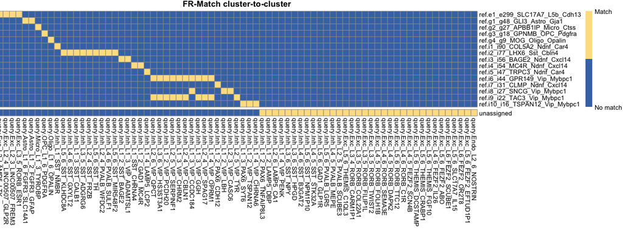

```r
## to visualize the one-directional matches
plot_FRmatch(rst.MTGtolayer1)
```

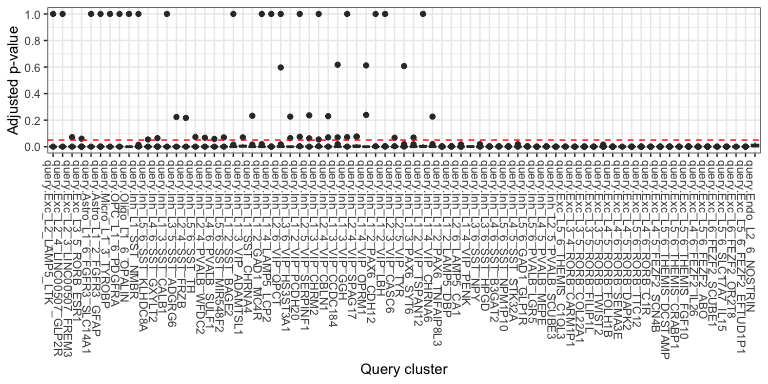

```r
## to visualize the adjusted p-values for each query cluster
plot_FRmatch(rst.MTGtolayer1, type = "padj")
```

It is interesting to see that the matching performance depends on the granularity and/or quality of the reference dataset. It is expected that the reference dataset is more comprehensive, such as the MTG data in this example, so that the one directional matching results in this direction align more with the bi-directional matching results.

# Other useful functions

## Friedman-Rafsky test

We also implemented our own function `FRtest()` for [Friedman-Rafsky (FR) test](https://projecteuclid.org/download/pdf_1/euclid.aos/1176344722) with customized options. FR test is a multivariate generalization of non-parametric two-sample test. It is a graphical model based on the concept of [minimum spanning tree](https://en.wikipedia.org/wiki/Minimum_spanning_tree) (MST). The MST provides a way to visualize high-dimensional clustered data in a low-dimensional visualization. A minimal working example of FR test and MST visualization is below.

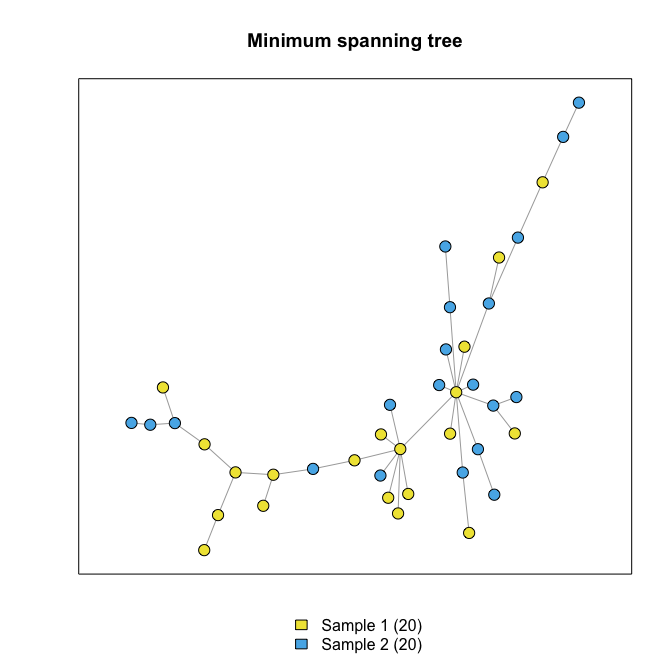

```
#>       runs runs.samp1 runs.samp2       stat    p.value
#> 20.0000000  7.0000000 13.0000000 -0.3378778  0.3677276
```

```r
# simulate some synthetic data from the same distribution
samp1 <- matrix(rnorm(1000), nrow = 50) #a 50-by-20 matrix: 50 dimensional, 20 data points
samp2 <- matrix(rnorm(1000), nrow = 50) #a 50-by-20 matrix: 50 dimensional, 20 data points
# FR test with MST plot
FRtest(samp1, samp2, plot.MST = TRUE, main = "Minimum spanning tree")
```

In the above test, the p-value suggests that no difference between the two simulated samples.

We encourage our users to visually examine their interested cell type clusters on MST plots.